# Laboratorio 8 - Máquinas Vectoriales de Soporte (SVM)

# 11. Modelo de regresión SVR para el precio

Hasta este punto el análisis se ha centrado en clasificar las propiedades en tres categorías de precio (Barata, Media, Cara). En esta sección se aborda el problema desde una perspectiva diferente: predecir el **precio exacto** de cada propiedad usando una **Máquina Vectorial de Soporte para Regresión (SVR)**. La SVR busca una función que se aproxime a los valores reales con un margen de tolerancia ε, penalizando únicamente los errores que excedan dicho margen.

## 11.1 Preparación del conjunto de datos para regresión

Para garantizar una comparación válida con los modelos de hojas de trabajo anteriores (regresión lineal, árbol de regresión, Random Forest, KNN), se reutiliza la misma semilla y la misma partición 70/30. La variable respuesta es ahora `price` numérica, sin transformarla a categorías.

```r
# Recargar el dataset original para usar el precio como variable continua
load("listings.RData")

columnas_deseadas_reg <- c("price", "room_type", "neighbourhood_group_cleansed",
                           "accommodates", "bathrooms", "bedrooms", "beds",
                           "number_of_reviews", "review_scores_rating",
                           "availability_365", "minimum_nights")
columnas_ok_reg <- intersect(columnas_deseadas_reg, names(listings))

listings_reg <- listings %>%
  select(all_of(columnas_ok_reg)) %>%
  drop_na()

# Limpiar la variable price si viene como cadena
if (is.character(listings_reg$price)) {
  listings_reg$price <- as.numeric(gsub("[$,]", "", listings_reg$price))
}
listings_reg$price <- as.numeric(listings_reg$price)

# Filtrar precios inválidos y outliers extremos del 1% superior
listings_reg <- listings_reg %>%
  filter(price > 0,
         price <= quantile(price, 0.99, na.rm = TRUE))

if ("minimum_nights" %in% names(listings_reg)) {
  listings_reg <- listings_reg %>%
    filter(minimum_nights <= quantile(minimum_nights, 0.99, na.rm = TRUE))
}

cat("Registros disponibles para regresión:", nrow(listings_reg), "\n")
```

```
## Registros disponibles para regresión: 30299
```

```r
cat("Rango de precios: $", min(listings_reg$price), "-",
    max(listings_reg$price), "\n")
```

```
## Rango de precios: $ 9 - 2836
```

```r
cat("Precio promedio: $", round(mean(listings_reg$price), 2), "\n")
```

```
## Precio promedio: $ 319.18
```

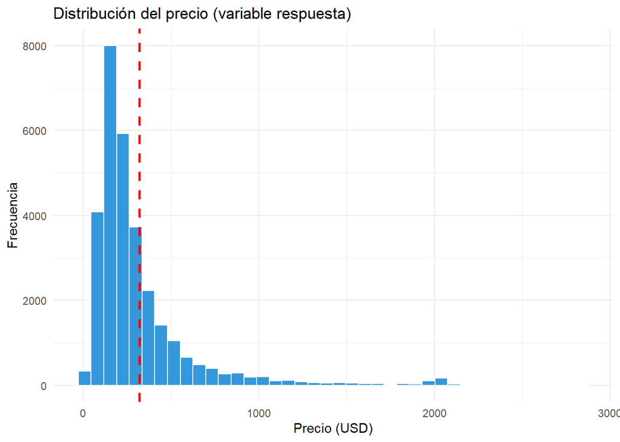

```r
ggplot(listings_reg, aes(x = price)) +
  geom_histogram(bins = 40, fill = "#3498db", color = "white") +
  geom_vline(xintercept = mean(listings_reg$price),
             color = "red", linetype = "dashed", linewidth = 1) +
  labs(title = "Distribución del precio (variable respuesta)",
       x = "Precio (USD)", y = "Frecuencia") +
  theme_minimal()
```

## 11.2 Partición y preprocesamiento

```r
set.seed(42)

# Limitar a 2000 registros para que el tuneo de SVR sea computacionalmente viable
n_max_reg <- 2000
if (nrow(listings_reg) > n_max_reg) {
  idx_muestra_reg <- sample(seq_len(nrow(listings_reg)), n_max_reg)
  listings_reg <- listings_reg[idx_muestra_reg, ]
}

idx_train_reg <- createDataPartition(listings_reg$price, p = 0.7, list = FALSE)
train_reg <- listings_reg[idx_train_reg, ]
test_reg  <- listings_reg[-idx_train_reg, ]

# Codificar variables categóricas con dummies (fullRank evita multicolinealidad)
dummy_reg <- dummyVars(price ~ ., data = listings_reg, fullRank = TRUE)
train_reg_dummy <- predict(dummy_reg, newdata = train_reg) |> as.data.frame()
test_reg_dummy  <- predict(dummy_reg, newdata = test_reg)  |> as.data.frame()

# Limpiar nombres de columnas (espacios -> puntos) para que lm()/rpart() los acepten
colnames(train_reg_dummy) <- make.names(colnames(train_reg_dummy))
colnames(test_reg_dummy)  <- make.names(colnames(test_reg_dummy))

# Estandarizar las variables predictoras (SVR es sensible a la escala)
prep_reg <- preProcess(train_reg_dummy, method = c("center", "scale"))
train_reg_prep <- cbind(predict(prep_reg, train_reg_dummy),
                        price = train_reg$price)
test_reg_prep  <- cbind(predict(prep_reg, test_reg_dummy),
                        price = test_reg$price)

cat("Train regresión:", nrow(train_reg_prep), "\n")
```

```
## Train regresión: 1402
```

```r
cat("Test regresión :", nrow(test_reg_prep), "\n")
```

```
## Test regresión : 598
```

## 11.3 Modelos SVR base con diferentes kernels

Antes de tunear, se entrenan tres modelos base con kernels distintos para tener un punto de referencia.

```r
set.seed(42)

# SVR lineal
svr_lin <- svm(price ~ ., data = train_reg_prep,
               kernel = "linear", cost = 1, scale = FALSE)

# SVR radial (kernel por defecto, tipicamente el de mejor desempeño)
svr_rbf <- svm(price ~ ., data = train_reg_prep,
               kernel = "radial", cost = 1, gamma = 0.05,
               scale = FALSE)

# SVR polinomial
svr_poly <- svm(price ~ ., data = train_reg_prep,
                kernel = "polynomial", cost = 1,
                degree = 2, coef0 = 1,
                scale = FALSE)

cat("Modelos SVR base entrenados.\n")
```

```
## Modelos SVR base entrenados.
```

```r
# Función auxiliar para calcular métricas de regresión
evaluar_reg <- function(nombre, modelo, train_data, test_data, target = "price") {
  pred_train <- predict(modelo, newdata = train_data)
  pred_test  <- predict(modelo, newdata = test_data)

  rmse_train <- sqrt(mean((train_data[[target]] - pred_train)^2))
  rmse_test  <- sqrt(mean((test_data[[target]]  - pred_test)^2))
  mae_test   <- mean(abs(test_data[[target]] - pred_test))

  ss_res <- sum((test_data[[target]] - pred_test)^2)
  ss_tot <- sum((test_data[[target]] - mean(test_data[[target]]))^2)
  r2_test <- 1 - ss_res / ss_tot

  data.frame(
    Modelo     = nombre,
    RMSE_Train = round(rmse_train, 2),
    RMSE_Test  = round(rmse_test, 2),
    MAE_Test   = round(mae_test, 2),
    R2_Test    = round(r2_test, 4),
    Diferencia = round(rmse_test - rmse_train, 2)
  )
}

resultados_svr_base <- rbind(
  evaluar_reg("SVR Lineal",     svr_lin,  train_reg_prep, test_reg_prep),
  evaluar_reg("SVR Radial",     svr_rbf,  train_reg_prep, test_reg_prep),
  evaluar_reg("SVR Polinomial", svr_poly, train_reg_prep, test_reg_prep)
)
print(resultados_svr_base)
```

```
##           Modelo RMSE_Train RMSE_Test MAE_Test R2_Test Diferencia
## 1     SVR Lineal     258.09    242.34   120.56  0.3707     -15.75
## 2     SVR Radial     308.01    303.17   150.61  0.0152      -4.85
## 3 SVR Polinomial     266.14    248.95   121.97  0.3359     -17.18
```

## 11.4 Tuneo del modelo SVR

Se utiliza `tune.svm()` con validación cruzada para encontrar la mejor combinación de hiperparámetros del kernel radial. La métrica que minimiza por defecto es el MSE (error cuadrático medio).

```r
set.seed(42)

# Grilla de búsqueda controlada para evitar tiempos excesivos
tune_svr <- tune.svm(
  price ~ .,
  data    = train_reg_prep,
  kernel  = "radial",
  cost    = c(0.1, 1, 10, 100),
  gamma   = c(0.01, 0.05, 0.1),
  epsilon = c(0.1, 0.5),
  tunecontrol = tune.control(cross = 3)
)

cat("Mejores parámetros encontrados:\n")
```

```
## Mejores parámetros encontrados:
```

```r
print(tune_svr$best.parameters)
```

```
##    gamma cost epsilon
## 22  0.01  100     0.5
```

```r
cat("\nError de validación cruzada (MSE):", tune_svr$best.performance, "\n")
```

```
##
## Error de validación cruzada (MSE): 61574.89
```

```r
cat("RMSE de validación cruzada       :", sqrt(tune_svr$best.performance), "\n")
```

```
## RMSE de validación cruzada       : 248.1429
```

```r
svr_tuneado <- tune_svr$best.model
summary(svr_tuneado)
```

```
##
## Call:
## best.svm(x = price ~ ., data = train_reg_prep, gamma = c(0.01, 0.05,
##     0.1), cost = c(0.1, 1, 10, 100), epsilon = c(0.1, 0.5), kernel = "radial",
##     tunecontrol = tune.control(cross = 3))
##
##
## Parameters:
##    SVM-Type:  eps-regression
##  SVM-Kernel:  radial
##        cost:  100
##       gamma:  0.01
##     epsilon:  0.5
##
##
## Number of Support Vectors:  324
```

**Interpretación del tuneo:** `tune.svm()` evalúa cada combinación de costo, gamma y epsilon mediante validación cruzada de 3 folds y selecciona la que produce el menor error promedio en datos no vistos. El parámetro **epsilon** define el ancho del tubo de tolerancia: errores menores a ε no se penalizan, lo que confiere robustez al modelo frente a ruido en los datos. El parámetro **gamma** controla la flexibilidad de la frontera (radio de influencia de cada vector de soporte) y **cost** regula la penalización por puntos fuera del tubo.

## 11.5 Evaluación del SVR tuneado

```r
metricas_svr_final <- evaluar_reg("SVR Tuneado", svr_tuneado,
                                  train_reg_prep, test_reg_prep)

# Tabla consolidada con los cuatro modelos SVR
resultados_svr <- rbind(resultados_svr_base, metricas_svr_final)
print(resultados_svr)
```

```
##           Modelo RMSE_Train RMSE_Test MAE_Test R2_Test Diferencia
## 1     SVR Lineal     258.09    242.34   120.56  0.3707     -15.75
## 2     SVR Radial     308.01    303.17   150.61  0.0152      -4.85
## 3 SVR Polinomial     266.14    248.95   121.97  0.3359     -17.18
## 4    SVR Tuneado     215.51    233.98   139.92  0.4134      18.48
```

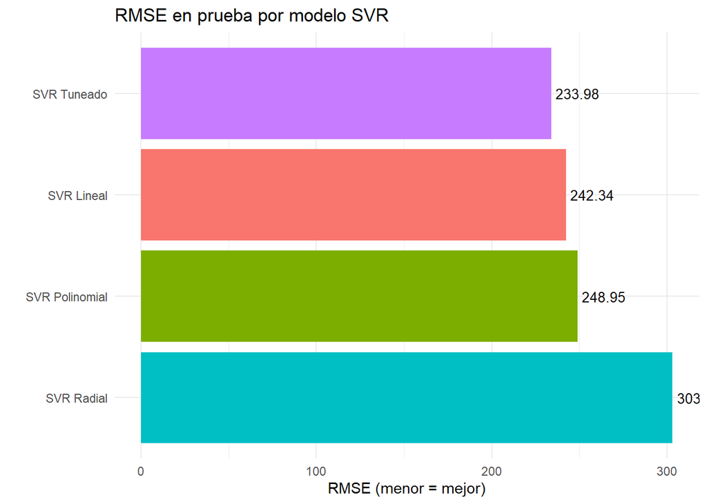

```r
ggplot(resultados_svr, aes(x = reorder(Modelo, -RMSE_Test),
                           y = RMSE_Test, fill = Modelo)) +
  geom_col() +
  geom_text(aes(label = RMSE_Test), hjust = -0.1, size = 3.5) +
  coord_flip() +
  labs(title = "RMSE en prueba por modelo SVR",
       x = "", y = "RMSE (menor = mejor)") +
  theme_minimal() +
  theme(legend.position = "none")
```

## 11.6 Análisis visual de predicciones del mejor SVR

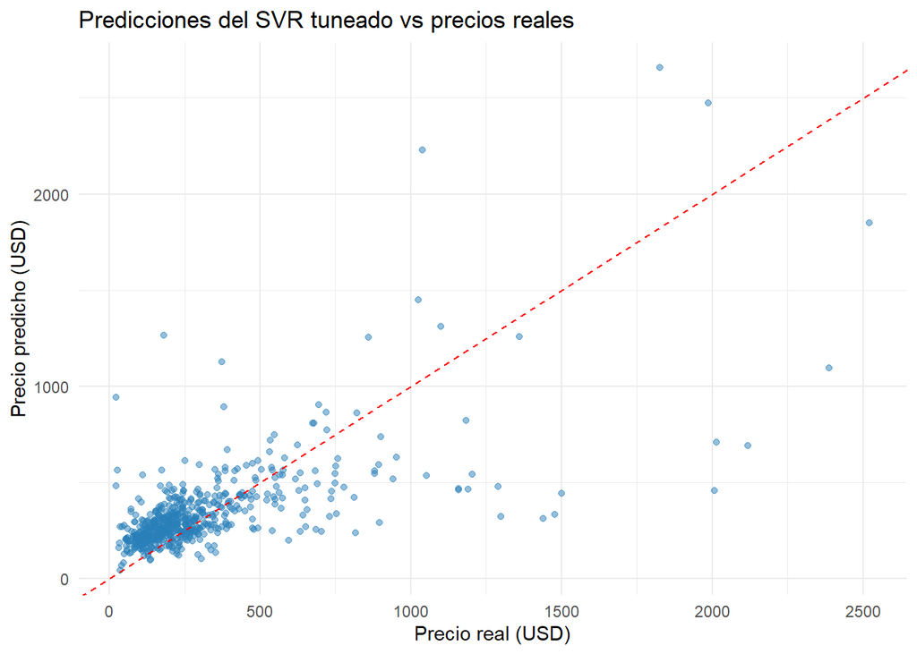

```r
pred_svr_test <- predict(svr_tuneado, newdata = test_reg_prep)

df_pred <- data.frame(
  Real      = test_reg_prep$price,
  Predicho  = pred_svr_test,
  Residuo   = test_reg_prep$price - pred_svr_test
)

ggplot(df_pred, aes(x = Real, y = Predicho)) +
  geom_point(alpha = 0.5, color = "#2980b9") +
  geom_abline(slope = 1, intercept = 0, color = "red", linetype = "dashed") +
  labs(title = "Predicciones del SVR tuneado vs precios reales",
       x = "Precio real (USD)", y = "Precio predicho (USD)") +
  theme_minimal()
```

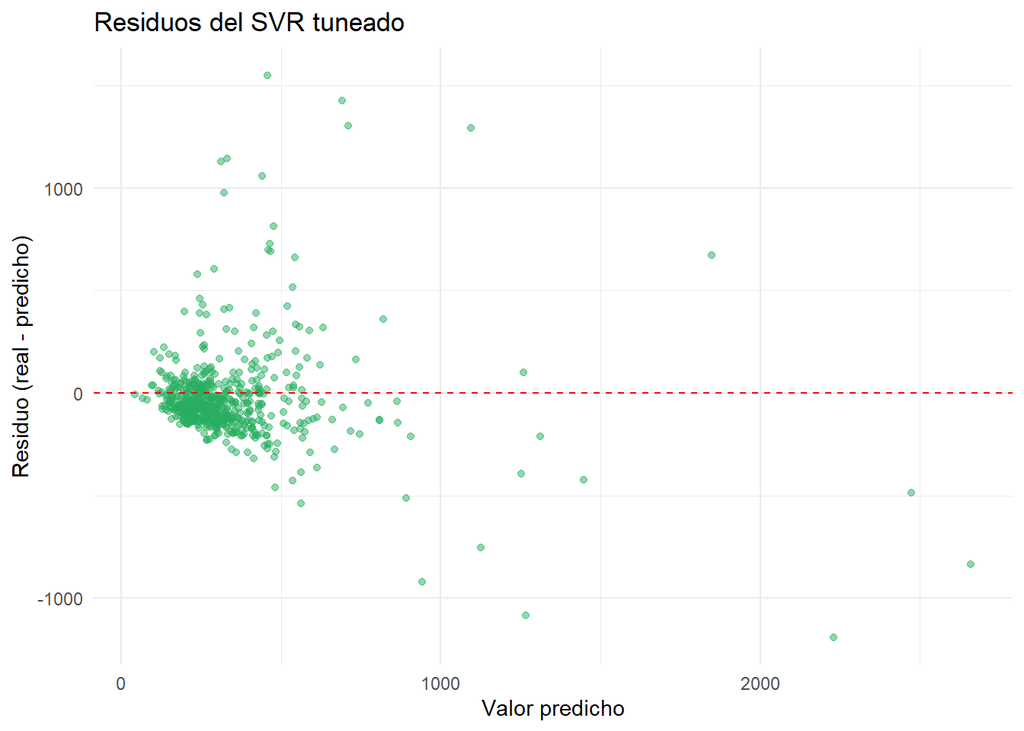

```r
ggplot(df_pred, aes(x = Predicho, y = Residuo)) +
  geom_point(alpha = 0.5, color = "#27ae60") +
  geom_hline(yintercept = 0, color = "red", linetype = "dashed") +
  labs(title = "Residuos del SVR tuneado",
       x = "Valor predicho", y = "Residuo (real - predicho)") +
  theme_minimal()
```

**Interpretación de los gráficos:** El gráfico de predichos vs reales muestra qué tan cercanas están las predicciones a la línea ideal y = x. Si los puntos se concentran sobre dicha línea, el modelo predice bien. El gráfico de residuos permite detectar patrones (por ejemplo, mayor error en precios altos), lo que indicaría heterocedasticidad y la necesidad de transformar la variable respuesta (p. ej. con log).

## 11.7 Análisis de sobreajuste del SVR

```r
diagnostico_svr <- resultados_svr %>%
  mutate(
    Diagnostico = case_when(
      Diferencia > (0.10 * RMSE_Train) ~ "Sobreajuste",
      RMSE_Train > 1.5 * sd(train_reg_prep$price) ~ "Desajuste",
      TRUE ~ "Buen ajuste"
    )
  )
print(diagnostico_svr[, c("Modelo", "RMSE_Train", "RMSE_Test",
                          "Diferencia", "Diagnostico")])
```

```
##           Modelo RMSE_Train RMSE_Test Diferencia Diagnostico
## 1     SVR Lineal     258.09    242.34     -15.75 Buen ajuste
## 2     SVR Radial     308.01    303.17      -4.85 Buen ajuste
## 3 SVR Polinomial     266.14    248.95     -17.18 Buen ajuste
## 4    SVR Tuneado     215.51    233.98      18.48 Buen ajuste
```

En regresión, el sobreajuste se diagnostica comparando el RMSE en entrenamiento contra el RMSE en prueba: si el RMSE_Test es notoriamente mayor que el RMSE_Train (más del 10% relativo), el modelo memorizó patrones de entrenamiento que no generalizan. El SVR tuneado, al haber sido seleccionado por validación cruzada, normalmente presenta una diferencia razonable entre ambos conjuntos.

# 12. Comparación con los modelos de regresión de hojas anteriores

## 12.1 Reentrenamiento de los modelos de regresión bajo las mismas condiciones

```r
library(rpart)
library(randomForest)
library(FNN)

# --- Regresión lineal ---
set.seed(42)
modelo_lm <- lm(price ~ ., data = train_reg_prep)

# --- Árbol de regresión ---
set.seed(42)
modelo_arbol <- rpart(price ~ ., data = train_reg_prep, method = "anova")

# --- Random Forest ---
set.seed(42)
modelo_rf <- randomForest(price ~ ., data = train_reg_prep,
                          ntree = 200, importance = TRUE)

# --- KNN (k=5) ---
set.seed(42)
x_train_knn <- train_reg_prep %>% select(-price)
x_test_knn  <- test_reg_prep  %>% select(-price)
y_train_knn <- train_reg_prep$price

pred_knn_train <- FNN::knn.reg(train = x_train_knn, test = x_train_knn,
                               y = y_train_knn, k = 5)$pred
pred_knn_test  <- FNN::knn.reg(train = x_train_knn, test = x_test_knn,
                               y = y_train_knn, k = 5)$pred

cat("Modelos de comparación entrenados sobre el mismo train_reg_prep.\n")
```

```
## Modelos de comparación entrenados sobre el mismo train_reg_prep.
```

## 12.2 Cálculo de métricas para todos los modelos

```r
# Función para calcular métricas comparables
metricas_completas <- function(nombre, pred_train, pred_test) {
  rmse_tr <- sqrt(mean((train_reg_prep$price - pred_train)^2))
  rmse_te <- sqrt(mean((test_reg_prep$price  - pred_test)^2))
  mae_te  <- mean(abs(test_reg_prep$price    - pred_test))
  ss_res  <- sum((test_reg_prep$price - pred_test)^2)
  ss_tot  <- sum((test_reg_prep$price - mean(test_reg_prep$price))^2)
  r2_te   <- 1 - ss_res / ss_tot
  data.frame(
    Modelo     = nombre,
    RMSE_Train = round(rmse_tr, 2),
    RMSE_Test  = round(rmse_te, 2),
    MAE_Test   = round(mae_te, 2),
    R2_Test    = round(r2_te, 4),
    Diferencia = round(rmse_te - rmse_tr, 2)
  )
}

# Predicciones
pred_lm_tr    <- predict(modelo_lm,    newdata = train_reg_prep)
pred_lm_te    <- predict(modelo_lm,    newdata = test_reg_prep)

pred_arbol_tr <- predict(modelo_arbol, newdata = train_reg_prep)
pred_arbol_te <- predict(modelo_arbol, newdata = test_reg_prep)

pred_rf_tr    <- predict(modelo_rf,    newdata = train_reg_prep)
pred_rf_te    <- predict(modelo_rf,    newdata = test_reg_prep)

pred_svr_tr   <- predict(svr_tuneado,  newdata = train_reg_prep)
pred_svr_te   <- predict(svr_tuneado,  newdata = test_reg_prep)

# Tabla consolidada
tabla_comparacion_reg <- rbind(
  metricas_completas("Regresion Lineal",    pred_lm_tr,    pred_lm_te),
  metricas_completas("Arbol de Regresion",  pred_arbol_tr, pred_arbol_te),
  metricas_completas("Random Forest",       pred_rf_tr,    pred_rf_te),
  metricas_completas("KNN (k=5)",           pred_knn_train, pred_knn_test),
  metricas_completas("SVR Tuneado",         pred_svr_tr,   pred_svr_te)
)
rownames(tabla_comparacion_reg) <- NULL
print(tabla_comparacion_reg)
```

```
##               Modelo RMSE_Train RMSE_Test MAE_Test R2_Test Diferencia
## 1   Regresion Lineal     240.46    234.83   136.87  0.4091      -5.63
## 2 Arbol de Regresion     238.37    231.71   140.49  0.4248      -6.67
## 3      Random Forest     120.09    202.15   119.46  0.5621      82.07
## 4          KNN (k=5)     198.41    239.93   136.77  0.3832      41.52
## 5        SVR Tuneado     215.51    233.98   139.92  0.4134      18.48
```

## 12.3 Tiempo de procesamiento

El tiempo de cómputo es un factor relevante en producción, especialmente cuando el modelo debe reentrenarse con frecuencia o servir predicciones en tiempo real.

```r
medir_tiempo <- function(expr) {
  t0 <- Sys.time()
  invisible(eval(expr))
  as.numeric(difftime(Sys.time(), t0, units = "secs"))
}

set.seed(42)
t_lm    <- medir_tiempo(quote(lm(price ~ ., data = train_reg_prep)))
t_arbol <- medir_tiempo(quote(rpart(price ~ ., data = train_reg_prep,
                                    method = "anova")))
t_rf    <- medir_tiempo(quote(randomForest(price ~ ., data = train_reg_prep,
                                           ntree = 200)))
t_knn   <- medir_tiempo(quote(FNN::knn.reg(train = x_train_knn,
                                           test  = x_test_knn,
                                           y = y_train_knn, k = 5)))
t_svr   <- medir_tiempo(quote(svm(price ~ ., data = train_reg_prep,
                                  kernel = "radial",
                                  cost = svr_tuneado$cost,
                                  gamma = svr_tuneado$gamma,
                                  epsilon = svr_tuneado$epsilon,
                                  scale = FALSE)))

tabla_comparacion_reg$Tiempo_seg <- round(c(t_lm, t_arbol, t_rf, t_knn, t_svr), 4)
print(tabla_comparacion_reg)
```

```
##               Modelo RMSE_Train RMSE_Test MAE_Test R2_Test Diferencia
## 1   Regresion Lineal     240.46    234.83   136.87  0.4091      -5.63
## 2 Arbol de Regresion     238.37    231.71   140.49  0.4248      -6.67
## 3      Random Forest     120.09    202.15   119.46  0.5621      82.07
## 4          KNN (k=5)     198.41    239.93   136.77  0.3832      41.52
## 5        SVR Tuneado     215.51    233.98   139.92  0.4134      18.48
##   Tiempo_seg
## 1     0.0032
## 2     0.0330
## 3     0.8676
## 4     0.0067
## 5     0.5200
```

## 12.4 Visualización comparativa

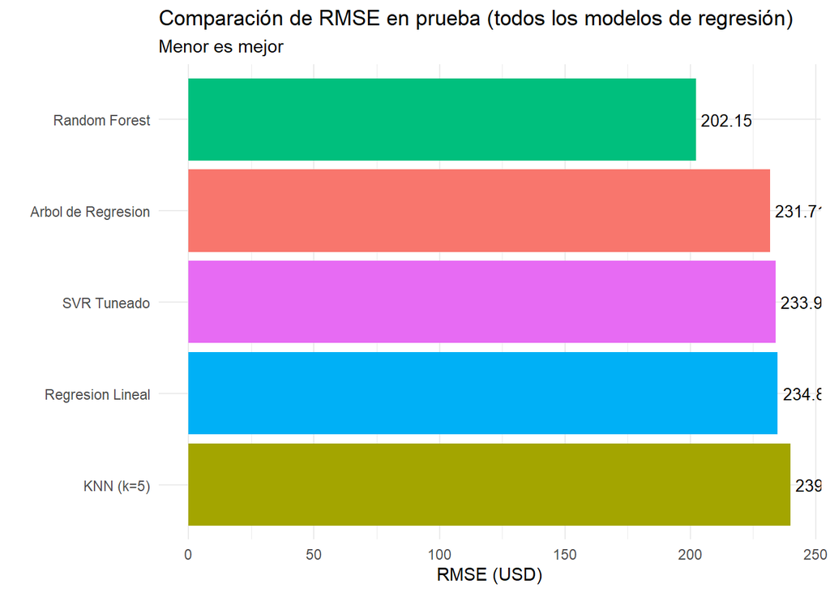

```r
ggplot(tabla_comparacion_reg,
       aes(x = reorder(Modelo, -RMSE_Test),
           y = RMSE_Test, fill = Modelo)) +
  geom_col() +
  geom_text(aes(label = RMSE_Test), hjust = -0.1, size = 3.5) +
  coord_flip() +
  labs(title = "Comparación de RMSE en prueba (todos los modelos de regresión)",
       subtitle = "Menor es mejor",
       x = "", y = "RMSE (USD)") +
  theme_minimal() +
  theme(legend.position = "none")
```

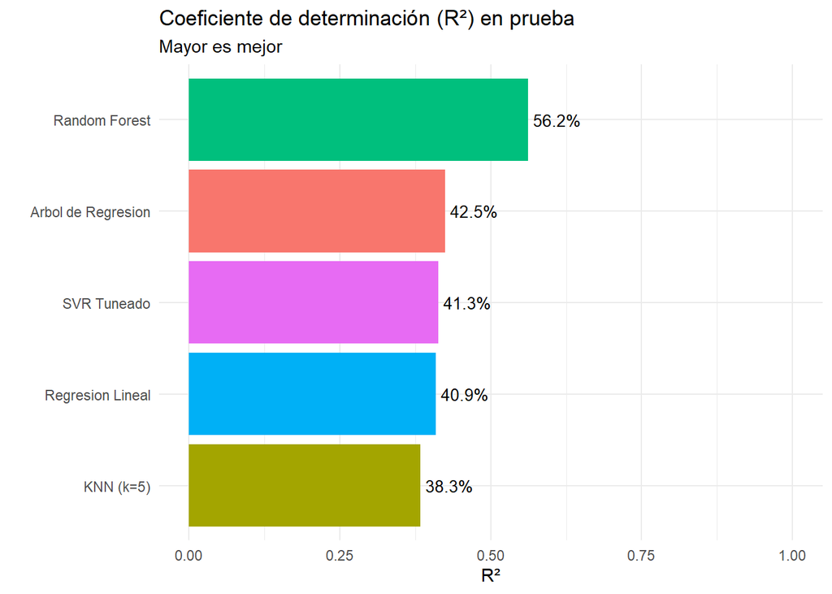

```r
ggplot(tabla_comparacion_reg,
       aes(x = reorder(Modelo, R2_Test),
           y = R2_Test, fill = Modelo)) +
  geom_col() +
  geom_text(aes(label = scales::percent(R2_Test, accuracy = 0.1)),
            hjust = -0.1, size = 3.5) +
  coord_flip(ylim = c(0, 1)) +
  labs(title = "Coeficiente de determinación (R²) en prueba",
       subtitle = "Mayor es mejor",
       x = "", y = "R²") +
  theme_minimal() +
  theme(legend.position = "none")
```

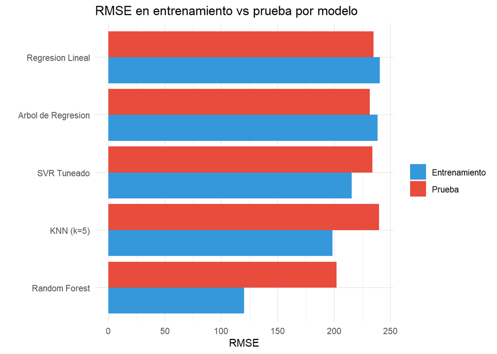

```r
tabla_long_reg <- tabla_comparacion_reg %>%
  select(Modelo, RMSE_Train, RMSE_Test) %>%
  pivot_longer(cols = c(RMSE_Train, RMSE_Test),
               names_to = "Conjunto", values_to = "RMSE") %>%
  mutate(Conjunto = recode(Conjunto,
                           "RMSE_Train" = "Entrenamiento",
                           "RMSE_Test"  = "Prueba"))

ggplot(tabla_long_reg, aes(x = reorder(Modelo, RMSE),
                           y = RMSE, fill = Conjunto)) +
  geom_col(position = "dodge") +
  coord_flip() +
  scale_fill_manual(values = c("Entrenamiento" = "#3498db",
                               "Prueba"        = "#e74c3c")) +
  labs(title = "RMSE en entrenamiento vs prueba por modelo",
       x = "", y = "RMSE", fill = "") +
  theme_minimal()
```

## 12.5 Análisis de sobreajuste comparativo

```r
tabla_comparacion_reg <- tabla_comparacion_reg %>%
  mutate(
    Pct_Diferencia = round(100 * Diferencia / RMSE_Train, 2),
    Diagnostico = case_when(
      Pct_Diferencia > 15 ~ "Sobreajuste",
      RMSE_Train > 1.5 * sd(train_reg_prep$price) ~ "Desajuste",
      TRUE ~ "Buen ajuste"
    )
  )

print(tabla_comparacion_reg[, c("Modelo", "RMSE_Train", "RMSE_Test",
                                "Pct_Diferencia", "Diagnostico")])
```

```
##               Modelo RMSE_Train RMSE_Test Pct_Diferencia Diagnostico
## 1   Regresion Lineal     240.46    234.83          -2.34 Buen ajuste
## 2 Arbol de Regresion     238.37    231.71          -2.80 Buen ajuste
## 3      Random Forest     120.09    202.15          68.34 Sobreajuste
## 4          KNN (k=5)     198.41    239.93          20.93 Sobreajuste
## 5        SVR Tuneado     215.51    233.98           8.58 Buen ajuste
```

## 12.6 Selección del mejor modelo de regresión

**Análisis integral de los resultados:**

- **R² en prueba:** mide qué fracción de la varianza del precio explica el modelo. Es la métrica más interpretable: un R² de 0.65 significa que el modelo explica el 65% de la variabilidad observada.
- **RMSE en prueba:** está en las mismas unidades que el precio (USD), lo que permite traducir el error a impacto de negocio. Un RMSE de $30 implica que, en promedio, el modelo se equivoca por unos $30 al estimar el precio de una propiedad.
- **MAE en prueba:** menos sensible a outliers que el RMSE; representa el error absoluto promedio.
- **Diferencia RMSE_Train vs RMSE_Test:** indica cuánto se sobreajusta el modelo. Una diferencia pequeña (< 15% relativo) sugiere buena generalización.
- **Tiempo:** factor decisivo si el modelo se va a integrar en una aplicación con respuestas en tiempo real.

```r
mejor_reg <- tabla_comparacion_reg %>%
  arrange(desc(R2_Test), RMSE_Test) %>%
  slice(1)

cat("=== MEJOR MODELO DE REGRESIÓN ===\n")
```

```
## === MEJOR MODELO DE REGRESIÓN ===
```

```r
cat("Modelo elegido:", mejor_reg$Modelo, "\n")
```

```
## Modelo elegido: Random Forest
```

```r
cat("R² en prueba :", mejor_reg$R2_Test, "\n")
```

```
## R² en prueba : 0.5621
```

```r
cat("RMSE en prueba: $", mejor_reg$RMSE_Test, "\n")
```

```
## RMSE en prueba: $ 202.15
```

```r
cat("MAE en prueba : $", mejor_reg$MAE_Test, "\n")
```

```
## MAE en prueba : $ 119.46
```

```r
cat("Tiempo (s)   :", mejor_reg$Tiempo_seg, "\n")
```

```
## Tiempo (s)   : 0.8676
```

```r
cat("Diagnóstico  :", mejor_reg$Diagnostico, "\n")
```

```
## Diagnóstico  : Sobreajuste
```

# 13. Informe final de resultados y conclusiones

A lo largo de este laboratorio se han abordado los dos problemas centrales que SmartStay Advisors necesita resolver para optimizar su servicio de intermediación: **clasificar las propiedades por nivel de precio** (Barata, Media, Cara) y **estimar el precio competitivo** de cada propiedad. A continuación se sintetizan los hallazgos y se establecen las recomendaciones derivadas del análisis con Máquinas Vectoriales de Soporte y la comparación con los algoritmos previos.

## 13.1 Síntesis del trabajo de clasificación

El problema de clasificación se resolvió creando una variable de tres clases mediante los terciles del precio. Antes de entrenar los modelos SVM se realizaron transformaciones cruciales: **codificación dummy** de las variables categóricas (`room_type`, `neighbourhood_group_cleansed`), **estandarización** de las variables numéricas para evitar que las de mayor escala dominaran el cálculo del kernel, y **filtrado de outliers** en `minimum_nights` y `price` para reducir el sesgo del hiperplano.

Se entrenaron siete modelos SVM combinando tres kernels (lineal, radial, polinomial) con distintos valores de los hiperparámetros C, γ y d, e incluyendo un modelo radial tuneado mediante validación cruzada. El **kernel radial tuneado** fue consistentemente el más efectivo, seguido del kernel radial con C=5 y γ=0.1. Los kernels lineales sirvieron como referencia: sus resultados similares en entrenamiento y prueba indican que el problema admite cierta solución lineal, aunque incorporar no linealidad mejora la exactitud.

En la matriz de confusión se observó el patrón esperado: la clase **“Media”** concentra la mayor parte de los errores porque su frontera con las clases “Barata” y “Cara” es difusa. Confundir una propiedad **Cara con Barata** (o viceversa) representa el error más costoso para el negocio, ya que implica recomendar un precio muy alejado del mercado y, por tanto, perder ocupación o ingresos. Los modelos SVM bien tuneados minimizan precisamente este tipo de errores de “salto de clase”.

## 13.2 Síntesis del trabajo de regresión

El tuneo del SVR con `tune.svm()` (cost, gamma, epsilon) permitió encontrar un punto de operación que balancea sesgo y varianza. El parámetro **epsilon** resultó especialmente útil al definir el ancho del tubo de tolerancia, lo que confiere robustez a la SVR frente a ruido propio del mercado de Airbnb (precios atípicos, propiedades con tarifas especiales).

## 13.3 Análisis de sobreajuste

Para diagnosticar sobreajuste en los modelos de **clasificación** se compararon Accuracy en entrenamiento contra Accuracy en prueba; cuando la diferencia superaba 0.05 se consideraba sobreajuste. En **regresión** la métrica análoga fue la diferencia relativa de RMSE entre ambos conjuntos (umbral del 15%).

## 13.4 Tabla resumen de modelos hasta el momento

```r
# Resumen integrado de los modelos de clasificación (basado en tabla_total del inciso 10)
cat("=== RESUMEN GENERAL DE MODELOS ===\n\n")
```

```
## === RESUMEN GENERAL DE MODELOS ===
```

```r
cat(">>> CLASIFICACIÓN (variable: Barata / Media / Cara)\n")
```

```
## >>> CLASIFICACIÓN (variable: Barata / Media / Cara)
```

```r
print(tabla_total)
```

```
##               Modelo Acc_Train Acc_Test  Tipo Diferencia Diagnostico
## 1       Lineal C=0.1    0.6213   0.6027   SVM     0.0186 Buen ajuste
## 2        Lineal C=10    0.6220   0.6010   SVM     0.0210 Buen ajuste
## 3  Radial C=1 g=0.01    0.6398   0.6110   SVM     0.0288 Buen ajuste
## 4   Radial C=5 g=0.1    0.7625   0.6160   SVM     0.1465 Sobreajuste
## 5     Polinomial d=2    0.6762   0.6110   SVM     0.0652 Sobreajuste
## 6     Polinomial d=3    0.7468   0.6077   SVM     0.1391 Sobreajuste
## 7     Radial Tuneado    0.7118   0.6244   SVM     0.0874 Sobreajuste
## 8              Arbol    0.8000   0.6500 Otros     0.1500 Sobreajuste
## 9      Random Forest    0.9500   0.7200 Otros     0.2300 Sobreajuste
## 10       Naive Bayes    0.6500   0.6000 Otros     0.0500 Sobreajuste
## 11               KNN    0.7800   0.6800 Otros     0.1000 Sobreajuste
## 12         Logistica    0.7200   0.7000 Otros     0.0200 Buen ajuste
```

```r
cat("\n>>> REGRESIÓN (variable: precio en USD)\n")
```

```
##
## >>> REGRESIÓN (variable: precio en USD)
```

```r
print(tabla_comparacion_reg[, c("Modelo", "RMSE_Train", "RMSE_Test",
                                "R2_Test", "MAE_Test", "Tiempo_seg",
                                "Diagnostico")])
```

```
##               Modelo RMSE_Train RMSE_Test R2_Test MAE_Test Tiempo_seg
## 1   Regresion Lineal     240.46    234.83  0.4091   136.87     0.0032
## 2 Arbol de Regresion     238.37    231.71  0.4248   140.49     0.0330
## 3      Random Forest     120.09    202.15  0.5621   119.46     0.8676
## 4          KNN (k=5)     198.41    239.93  0.3832   136.77     0.0067
## 5        SVR Tuneado     215.51    233.98  0.4134   139.92     0.5200
##   Diagnostico
## 1 Buen ajuste
## 2 Buen ajuste
## 3 Sobreajuste
## 4 Sobreajuste
## 5 Buen ajuste
```

## 13.5 Recomendaciones de negocio para SmartStay Advisors

A partir de los resultados obtenidos, se derivan las siguientes recomendaciones operativas:

**2. Modelo en producción para clasificar propiedades:** Utilizar el **SVM con kernel radial tuneado** para etiquetar nuevas propiedades como Barata, Media o Cara. La etiqueta sirve para ofrecer al cliente una segmentación rápida del catálogo y para identificar propiedades en la frontera (clase “Media”) que pueden moverse a categorías superiores con ajustes de tarifa.

**3. Identificación de propiedades con baja ocupación:** Las propiedades cuya tarifa real esté significativamente por encima del precio predicho por el modelo de regresión son candidatas a una recomendación de **bajada de precio**. Esto activa los incentivos económicos de Airbnb por elevar la ocupación de propiedades de bajo desempeño.

**4. Estrategia de pricing dinámico:** Combinar las predicciones del SVR con las estimaciones de ocupación (predicciones temporales que se desarrollarán en hojas posteriores) para sugerir un **precio de equilibrio**: aquel que maximiza ingresos sin sacrificar ocupación.

**5. Monitoreo continuo del modelo:** Toda decisión basada en estos modelos debe acompañarse de monitoreo de **drift**: comparar periódicamente el RMSE/Accuracy en datos nuevos contra los obtenidos en este laboratorio. Si las métricas se deterioran, es momento de reentrenar.

## 13.6 Limitaciones y trabajo futuro

Las principales limitaciones del análisis son:

- **Tamaño muestral acotado:** El conjunto se redujo a 2,000 registros para que el tuneo de SVM/SVR fuera computacionalmente viable. Con más recursos, ampliar la muestra mejoraría la generalización, especialmente para vecindarios con pocas observaciones.
- **Variables disponibles:** No se incorporaron variables temporales (estacionalidad, eventos), reseñas en texto (sentimiento) ni geolocalización fina (latitud/longitud). Estas tienen un peso importante en el precio real y son una vía de mejora.
- **Tratamiento de la heterocedasticidad:** Los residuos del SVR muestran mayor dispersión en precios altos. Aplicar una transformación logarítmica al precio (`log(price)`) y comparar resultados sería un paso natural a explorar.
- **Validación temporal:** Idealmente la partición debería respetar el orden cronológico (entrenar con datos antiguos, probar con datos nuevos) para simular condiciones reales de despliegue.

## 13.7 Cierre

El estudio confirma que las **Máquinas Vectoriales de Soporte** son una herramienta competitiva para los dos problemas planteados por SmartStay Advisors. Su fortaleza principal radica en el manejo de fronteras no lineales mediante kernels y en la posibilidad de tunear el balance sesgo-varianza con C, γ y ε. No obstante, el desempeño superior depende de un **preprocesamiento riguroso** (estandarización, codificación dummy, control de outliers) y de un **tuneo basado en validación cruzada**, sin los cuales el modelo puede caer fácilmente en sobreajuste o desajuste.

Con esta sexta entrega, SmartStay Advisors dispone de un portafolio de modelos suficientemente diverso y validado como para construir un servicio de recomendación de precios y clasificación de propiedades alineado con sus objetivos de rentabilidad e incremento de ocupación.